# NP AMR analyses

Sunheng Kaing & Nicholas Croucher

2026-05-28

# Load data from project

Import sample data from project

# Analysis of short-read data

## Quality control of data and association with sample information

### Identify species with Kraken and Bracken

Analysis of the short reads used the `qc-short-read` pipeline (revision 103cba2a10; v1.0.2), which depends upon:

- fastqc (v0.12.1)
- multiqc (v1.19)
- kraken2 (v2.1.3)
- bracken (v2.8)

The results are stored for projects 6310 and 6588.

Download data from the Drachenstein study; results are available here:

This run failed for seven isolates, which were subsequently re-run.

### Assemble reads with SPAdes and unicycler

Analysis of the short reads used the `assembly-unicycler-short-read` pipeline (v1.2.5; commit 92464961e453d624e88e69da06670638fb90ede0), developed from the bacass pipeline (v2.5.0; https://zenodo.org/records/17378847), which depends upon:

- QUAST (v5.0.2)
- Unicycler (v0.5.1)
- SPAdes (v4.0.0)

The results are stored for projects 6310 and 6588.

Assemble data from the Drachenstein study; results are available here:

### Annotate assemblies with Bakta

The assemblies were annotated using Bakta (version 1.11.0).

This was also run on the Drachenstein isolates, after 1427/1429 isolates were successfully downloaded and assembled:

### Evaluate assemblies with Quast

Assembly statistics were calculated with Quast (version 5.0.2).

### Quality control parameters for genomic assemblies

We will use these two files to merge getting chronological data set.

```r
sample_assemblies_df <-
  dplyr::right_join(as_tibble(assembly_stats_df),
             as_tibble(sample_df),
             by = "npg_run_id")

minimum_length <- 1725000
maximum_length <- 2250000
n50_threshold <- 80000
```

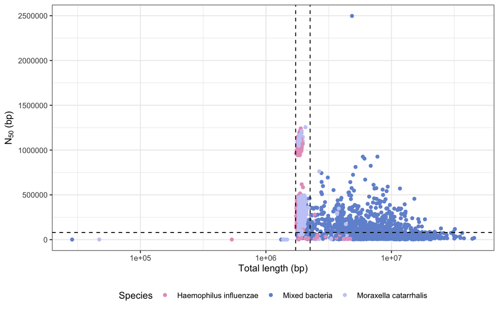

These thresholds were used to remove low-quality assemblies:

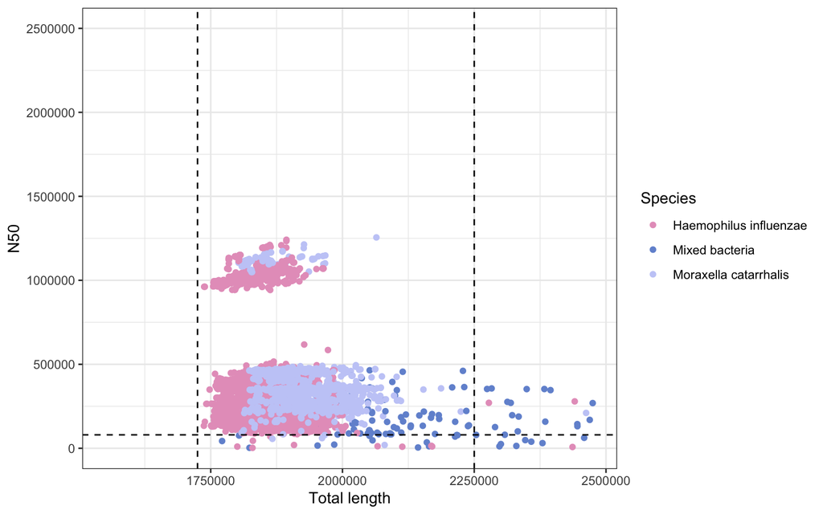

### Identification of the species present in each sequence dataset

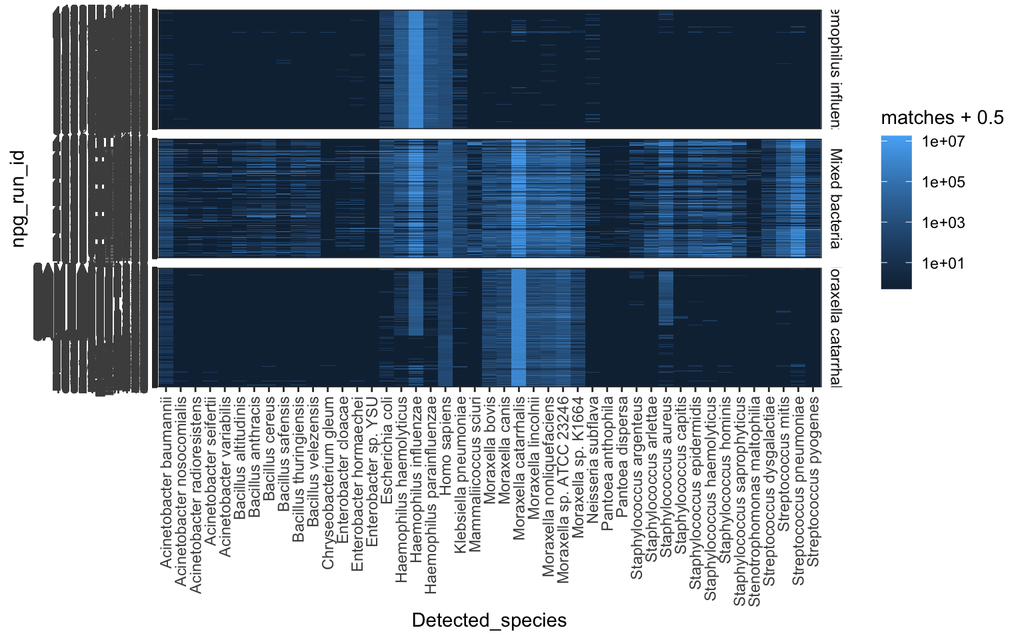

### Identification of high-quality single isolate datasets

The single isolate sequences of *M. catarrhalis* and *H. influenzae* should contain relatively little sequence from other species - any such presence represents contamination.

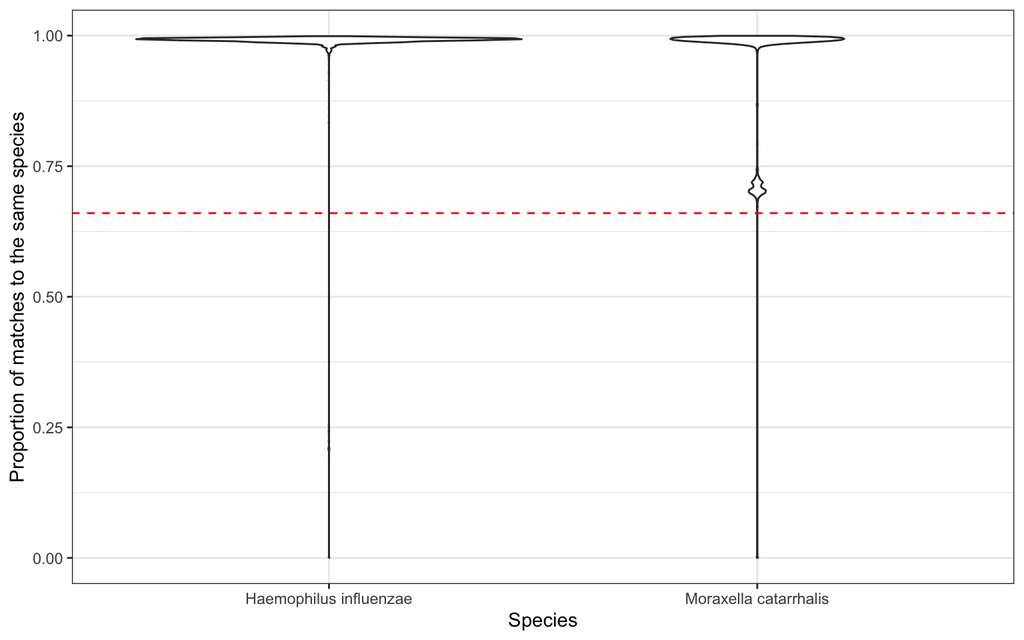

Bracken only matched 60-75% of the reads from many *M. catarrhalis* datasets to the expected species. In some cases, this was because reads were instead assigned to *Moraxella* sp. ATCC 23246. In other cases, there appeared to be a high level of contamination with *Escherichia coli* or *H. influenzae*. Therefore filtering instead used the proportion of reads assigned to the expected genus:

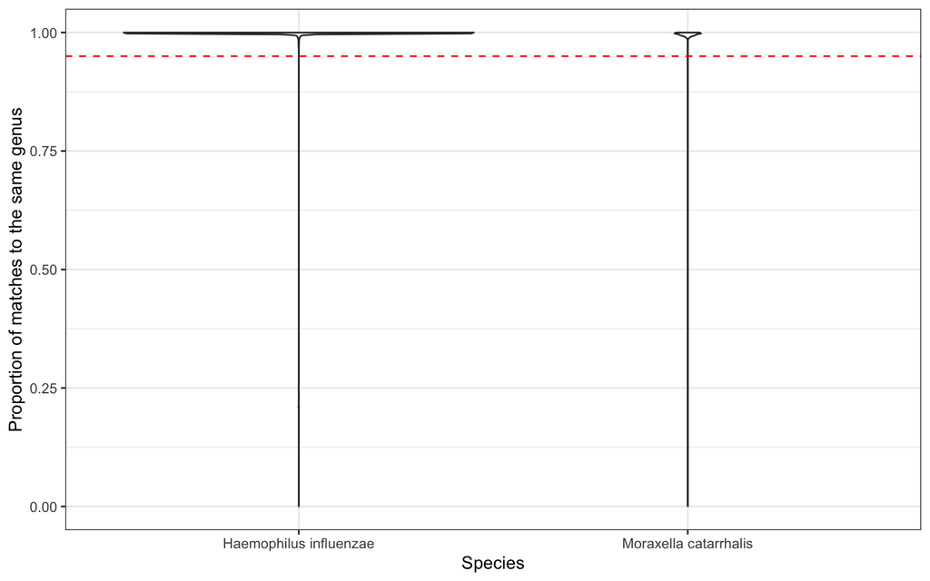

### Final filtering on sequence characteristics

We want to keep samples meeting the criteria:

| Expected_species | Number of genomes | Expected assembly length | N50 above threshold | Not contaminated | Correct species | Passing all criteria |
| --- | --- | --- | --- | --- | --- | --- |
| Haemophilus influenzae | 4260 | 4234 | 4227 | 4233 | 4240 | 4219 |
| Moraxella catarrhalis | 2539 | 2479 | 2481 | 2483 | 2523 | 2462 |

### Output lists of high-quality single isolate sequences

Here we generate the final list of QC-passing *M. catarrhalis* isolates:

Here we generate the final list of QC-passing *H. influenzae* isolates:

### Epidemiological characteristics of filtered single-isolate dataset

[output not shown]

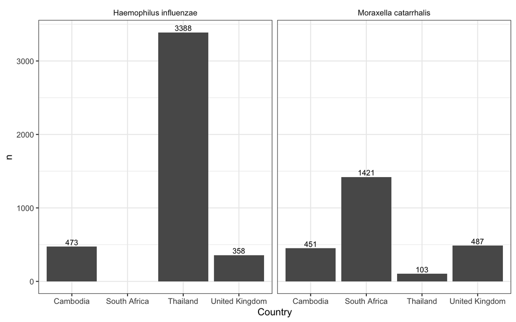

## Use PopPUNK to categorise isolates

### Definition of the *M. catarrhalis* PopPUNK scheme

The *M. catarrhalis* population can be divided into serosensitive and seroresistant isolates. The serosensitive isolates are associated with deeper branches than the seroresistant isolates. Therefore it is necessary to define separate PopPUNK schemes for these two types.

First, the distances were calculated for all the *M. catarrhalis* genomes using PopPUNK version 2.7.7:

The distance distribution shows:

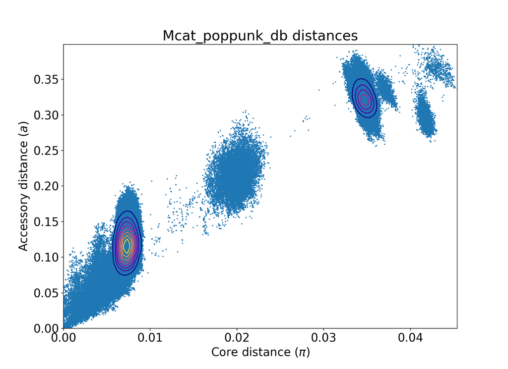

Pairwise distance distribution

An initial refinement was used to identify a boundary separating the serosensitive and seroresistant isolates. This required searching the region bounded by (0.025,0.25) and (0.0325,0.275):

This results in a boundary:

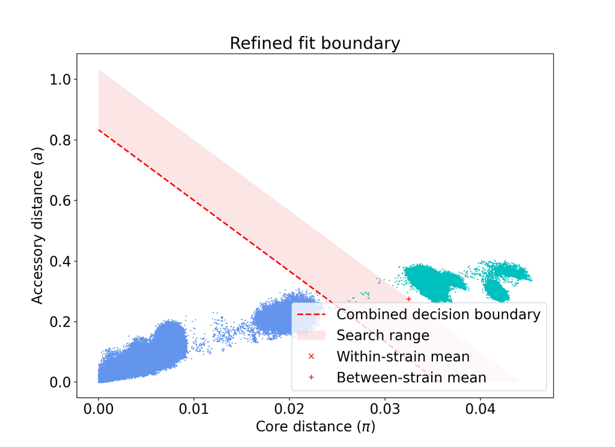

Boundary

This classification can be visualised:

These isolates can be viewed in [microreact](https://microreact.org/project/hQ9WcBim9Yspg9vEvVPWqr-moraxella-population-structure) - the file is available as Mcat_seroClassification_viz.microreact.

In accordance with [previous](https://www.microbiologyresearch.org/content/journal/mgen/10.1099/mgen.0.001488) [work](https://www.microbiologyresearch.org/content/journal/mgen/10.1099/mgen.0.000820), The isolates can therefore be classified as seroresistant (cluster 1), serosensitive (cluster 2), atypical cluster 1 (cluster 3), and atypical cluster 2 (cluster 4).

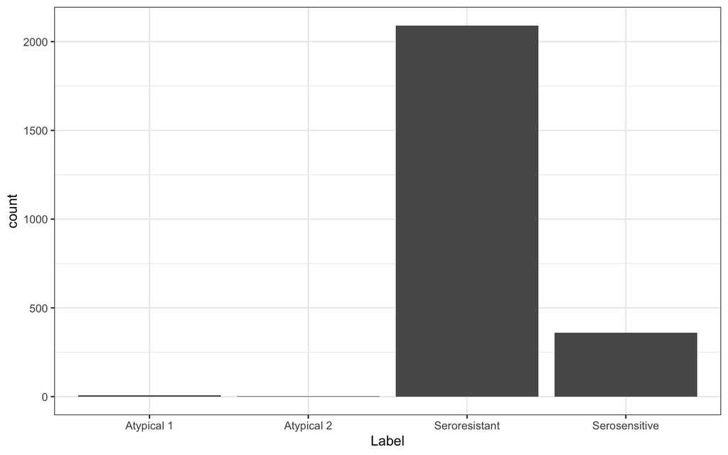

Separate PopPUNK databases can be generated for the seroresistant and serosensitive isolates:

First, a DBSCAN model can be fitted to the smaller set of serosensitive isolates:

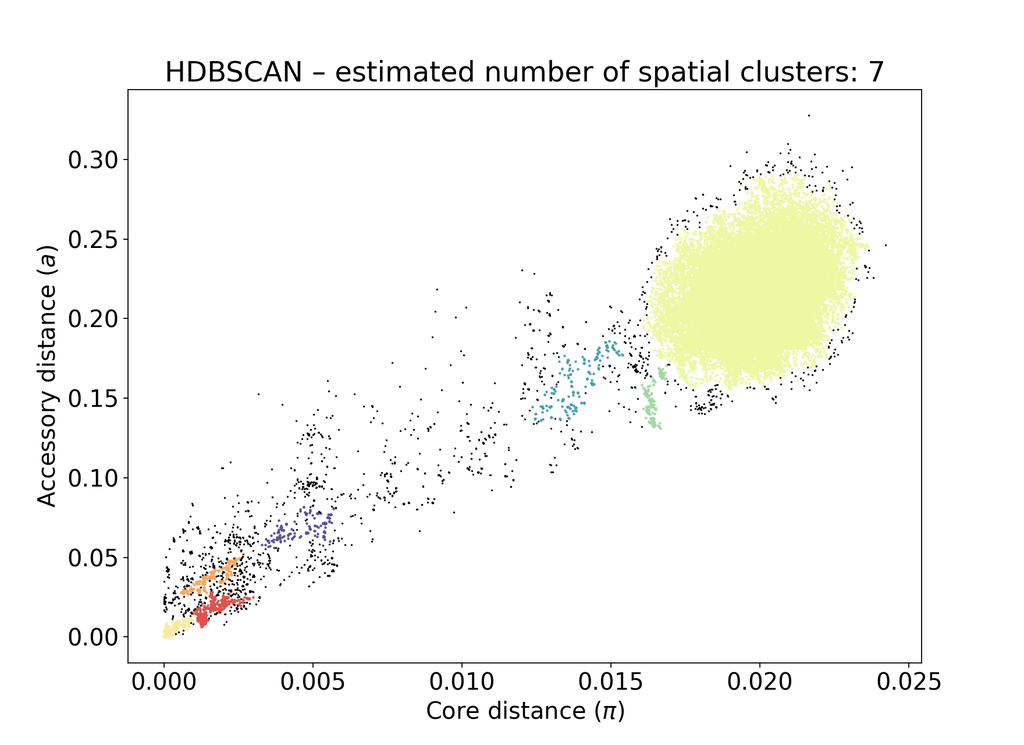

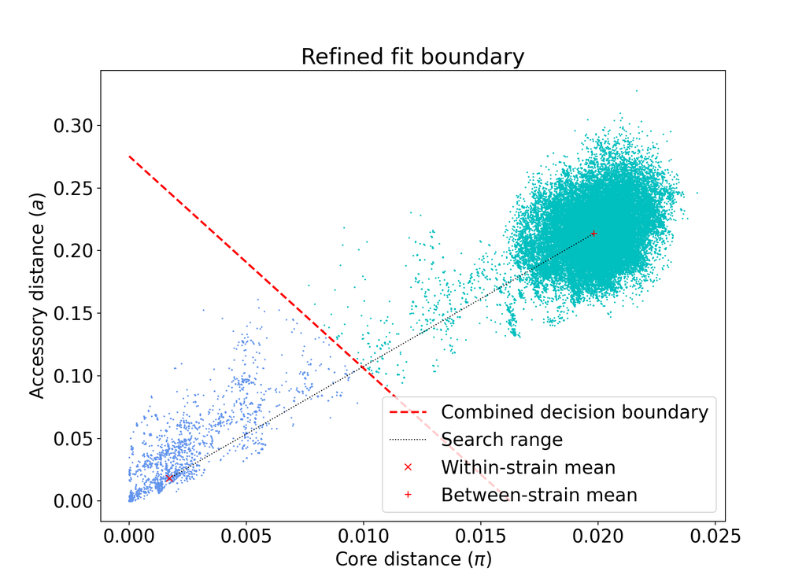

Refined fit to serosensitive isolates

The clustering was then visualised:

A DBSCAN model can also be fitted to the seroresistant isolates:

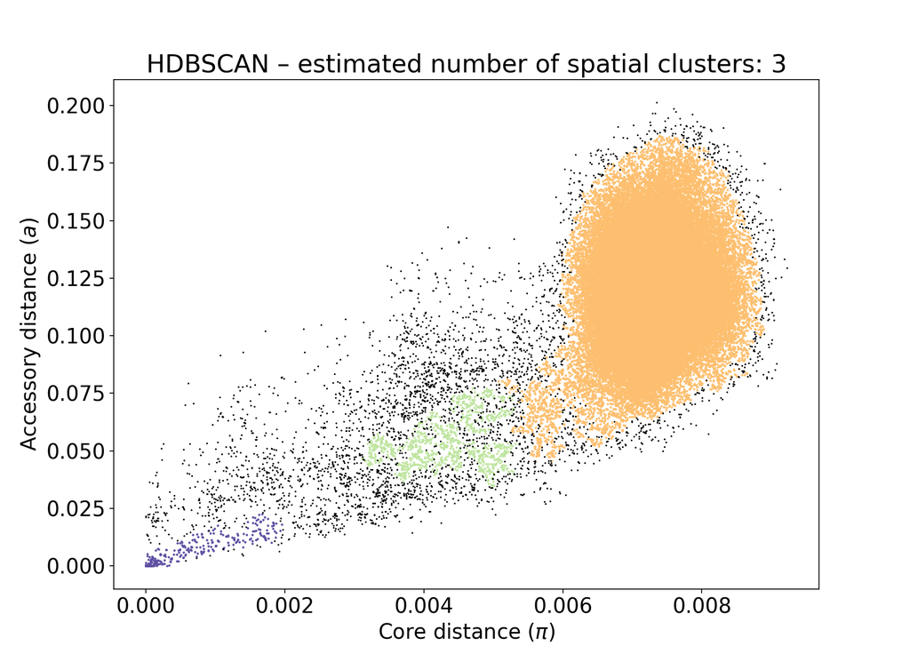

DBSCAN fit to seroresistant isolate

The distance distribution for the seroresistant isolates demonstrates the isolates are <1% divergent in the core genome, with ~12.5% divergence in the accessory genome.

The model can be refined for the seroresistant isolates using the same approach as for the serosensitive isolates. The DBSCAN cluster positions used to guide the refined fit were (0.06521943,0.03128192) for the within-strain distances, and (0.78877825,0.58528107) for the between-strain distances. The boundary defined by the within-strain distances was moved away from the origin by a negative shift of 20%, to make the fit analogous with the serosensitive fit:

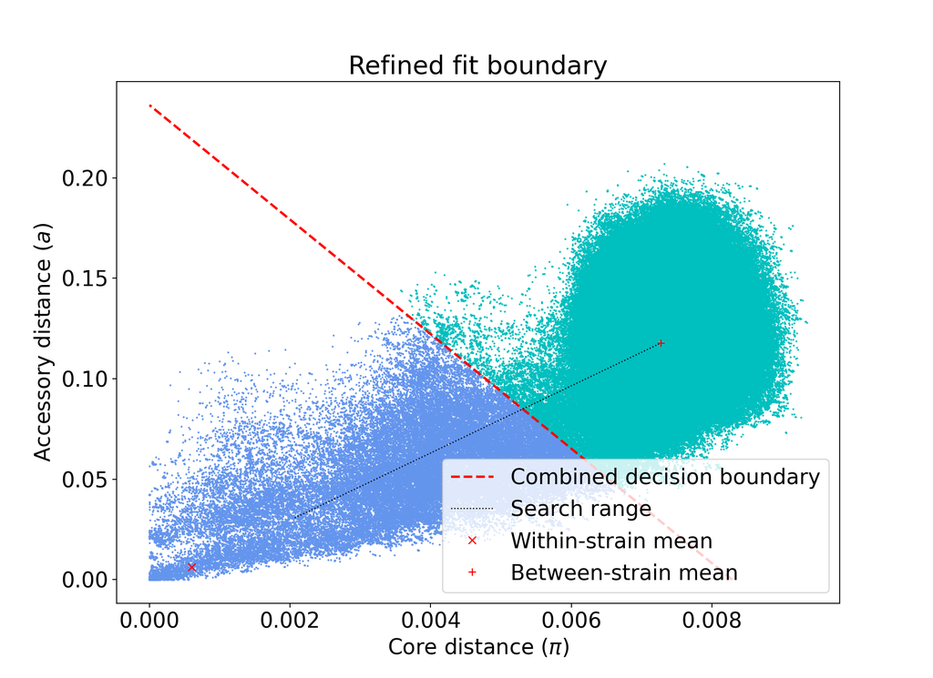

Refined fit to seroresistant isolates

The output can then be visualised, and the strains classified:

The output is available to view on [microreact](https://microreact.org/project/cYSZ1g2Scstfbg1hVpoe7r-seroresistant-moraxella-poppunk) using the file.

Finally, we arrive at a classification of all *Moraxella catarrhalis* isolates:

```
##
##
## Expected output: 2462
##
## Observed output: 2462
```

### Querying the *H. influenzae* PopPUNK scheme

The *H. influenzae* v2 [database](https://www.bacpop.org/poppunk-databases/) was queried:

This generated this distance distribution:

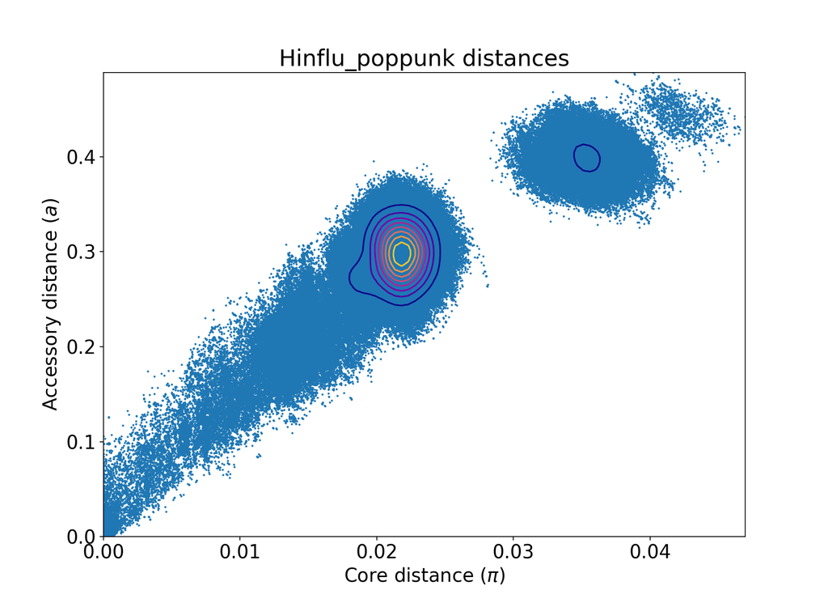

Haemophilus query distance distribution

The output was visualised:

The output can be viewed on [Microreact](https://microreact.org/project/qCSg4Ut9QYfAXo3tK3gTDu-h-influenzae-poppunk), generated from this file.

The clustering can be processed:

## Analyse the distribution of AMR genes

After ran the Abritamr too of antibiotic resistance analysis for *H.influenzae* then We will import the SAfrica_amr_sumary.txt and amr_summary.txt for find the antibiotic resistance of each isolated *H.influenzae* strain from South Africa, United Kingdom, Cambodia, and Thailand. Finally, we will generate CSV file to be input in Microreact data show.

### Analysis with abritamr

```
## Not all Mcat isolates in AMR output
```

### Compare the resistance between *M. cattarrhalis* types

We try to find resistance genes of *M. cattarrhalis* in the serosensitive and seroresistant populations

### Phylogeny of *blaBRO* in *M. catarrhalis*

TO DO

### Phylogeny of *hmm* in *H. influenzae*

TO DO

## Identify capsules in the single isolate datasets

### Analysis of *H. influenzae* capsules

We will find the capsule of each isolated *H. influenzae* strains with bioinformatic Hicap software

## Initialise microreact epidemiological data frames

### Distribution of resistance by country for *H. influenzae*

We try to find % of isolates carrying different resistance genes of *H.influenzae* in different countries

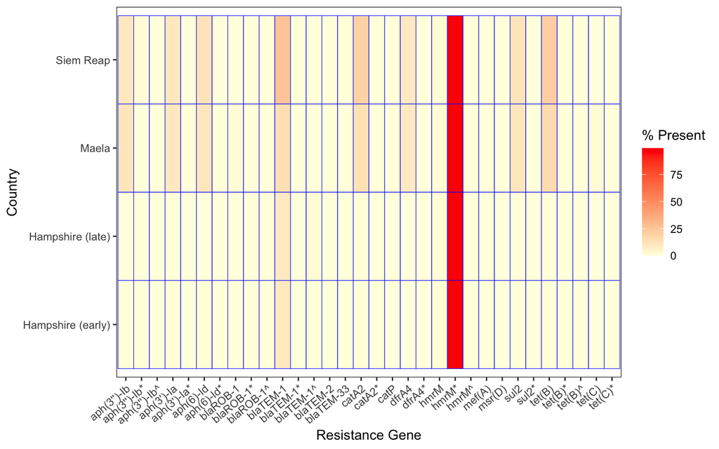

### Distribution of resistance by country for *M. cattarrhalis*

We try to find % of isolates carrying different resistance genes of *M. cattarrhalis* in different countries

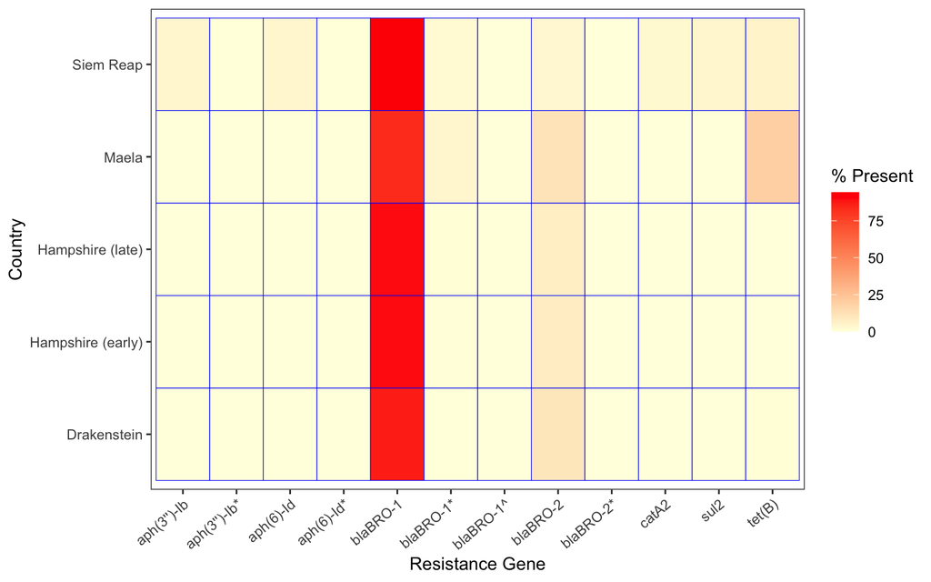

### Compare resistance between *H. influenzae* and *M. catarrhalis* across locations

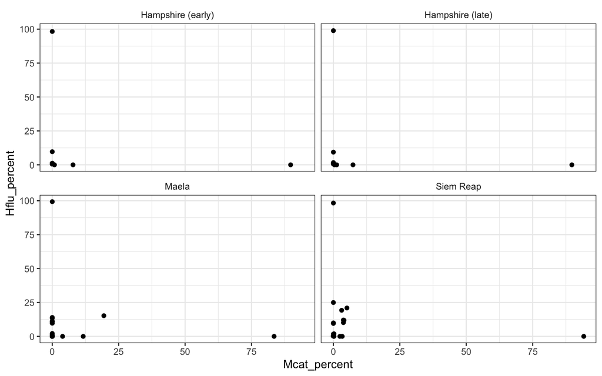

## Add plot of serotype distribution across locations

TO DO

## Plasmid clustering and phylogeny analysis

### Analysis of genomic data with MOB suite

### Phylogenetic analysis of MOB suite types

Plasmids of *M.cattarrhalis* -https://microreact.org/project/6dXeUstQx3WxRPNDgfYL3t-moraxella-population-plasmid-ae018 -https://microreact.org/project/4D7xzXhw5V4N95ffR75MqU-moraxella-population-plasmid-ac411 -https://microreact.org/project/wPkFU4AGB7TqN6tuQDrUm2-moraxella-population-plasmid-ab778 -https://microreact.org/project/oiYRhnTzRsQnb17aas35Mv-moraxella-population-plasmid-ag261

Plasmids of *H.influenzae*

-https://microreact.org/project/jYaSJhLnw5eKNjE38rV23v-h-influenzae-plasmid-af100 -https://microreact.org/project/7vhwRNj1BUmR9aycoxxxpP-h-influenzae-plasmid-ae025 -https://microreact.org/project/fPBZNbs2Ap8uJR4iDN1g4C-h-influenzae-plasmid-ac497 -https://microreact.org/project/bLcqpWEMmer44AnEJXKkyh-h-influenzae-plasmid-ab947 -https://microreact.org/project/7Y77gxEyjWP46GtEmD7WUr-h-influenzae-plasmid-ab261 -https://microreact.org/project/4Q9MF4sBFJSNFmhSEWX8Hr-h-influenzae-plasmid-ab946 -https://microreact.org/project/1pNRDtKv8GRVcZ8BH9yBVr-h-influenzae-plasmid-af098 -https://microreact.org/project/2xzdSLxUew1rWPPazcUVZH-h-influenzae-plasmid-ae169

These trees show clear within-type heterogeneity.

### Clustering with mge-cluster

The plasmid sequences were then clustered with mge-cluster software:

We calculate the plasmid sizes:

Read in the gene presence/absence matrix for *H. influenzae*:

### Pangenome curve for *H. influenzae*

TO DO

### Analysis of *M. catarrhalis* gene content

Read in the gene presence/absence matrix:

Read in the gene presence/absence matrix for *H. influenzae*:

We plot the overall size distribution of the plasmids:

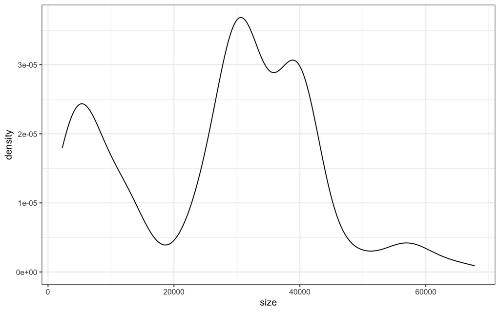

We plot the plasmids by size and sequence similarity:

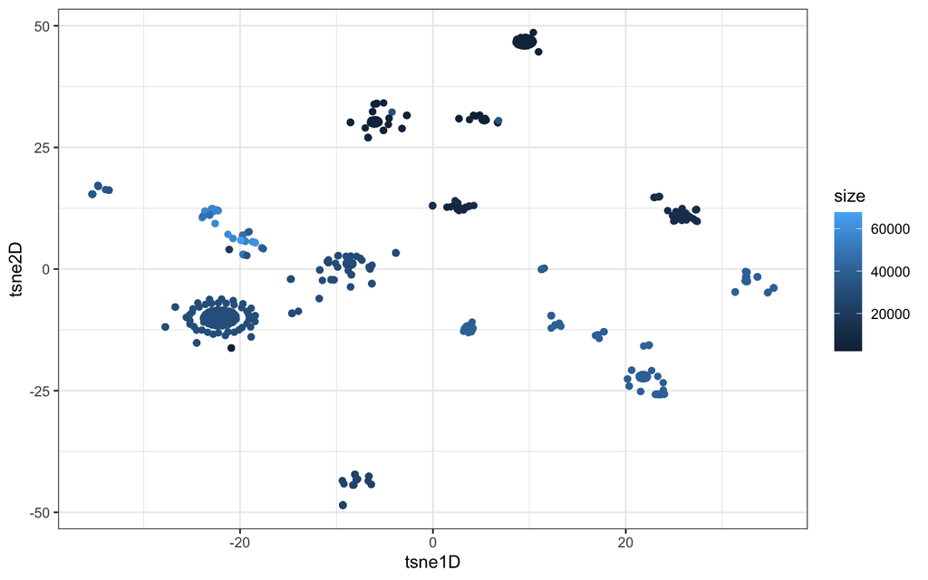

This shows the smallest plasmids are at the top.

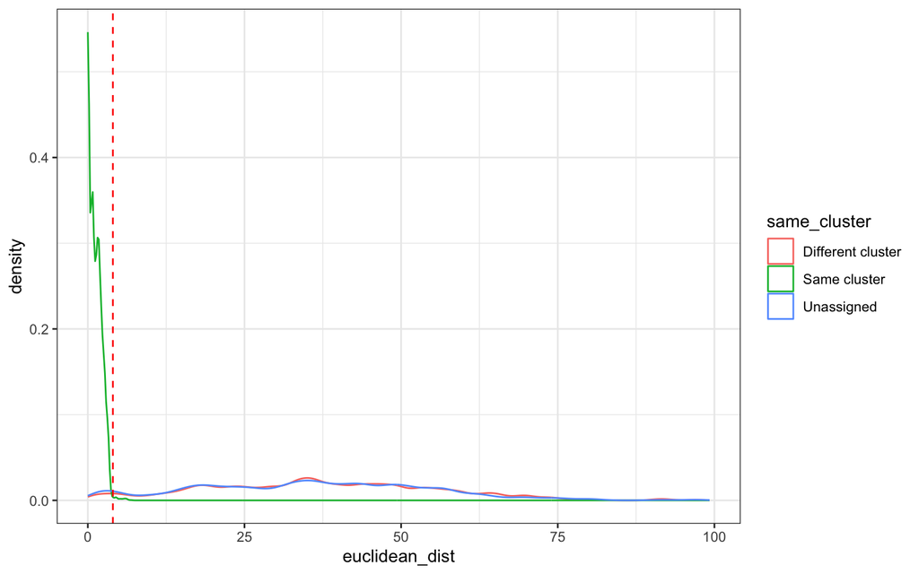

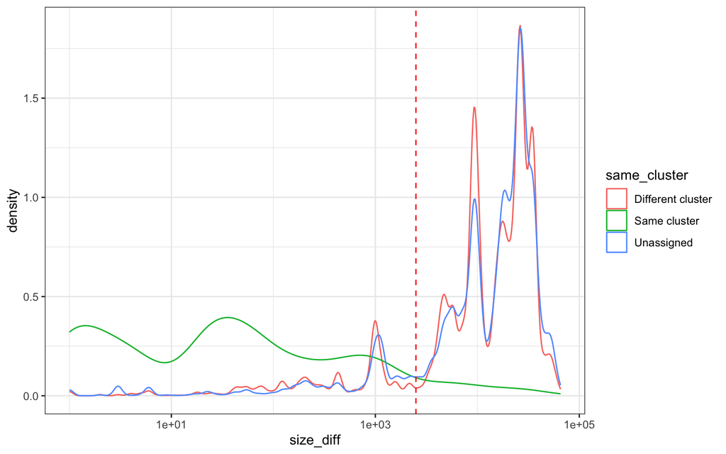

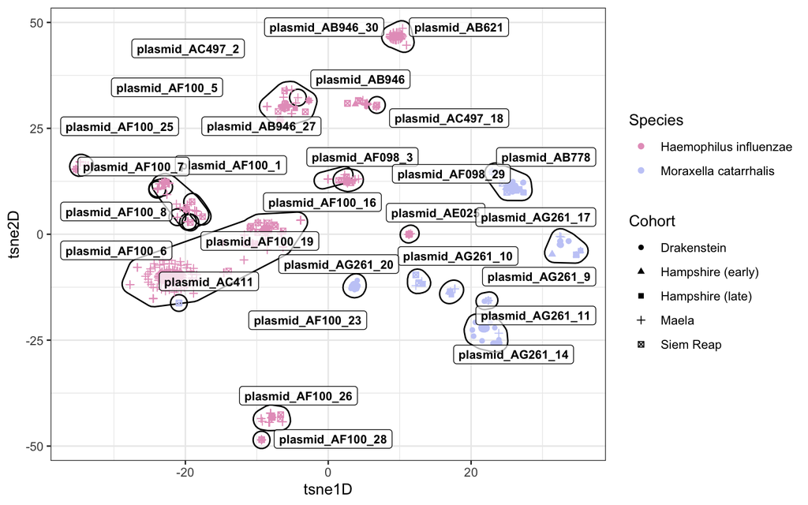

Add the mobsuite information to the microreact epidemiology CSV files:

### Plot plasmid distribution across cohorts

TO DO

### Association between plasmids and resistance in *H. influenzae*

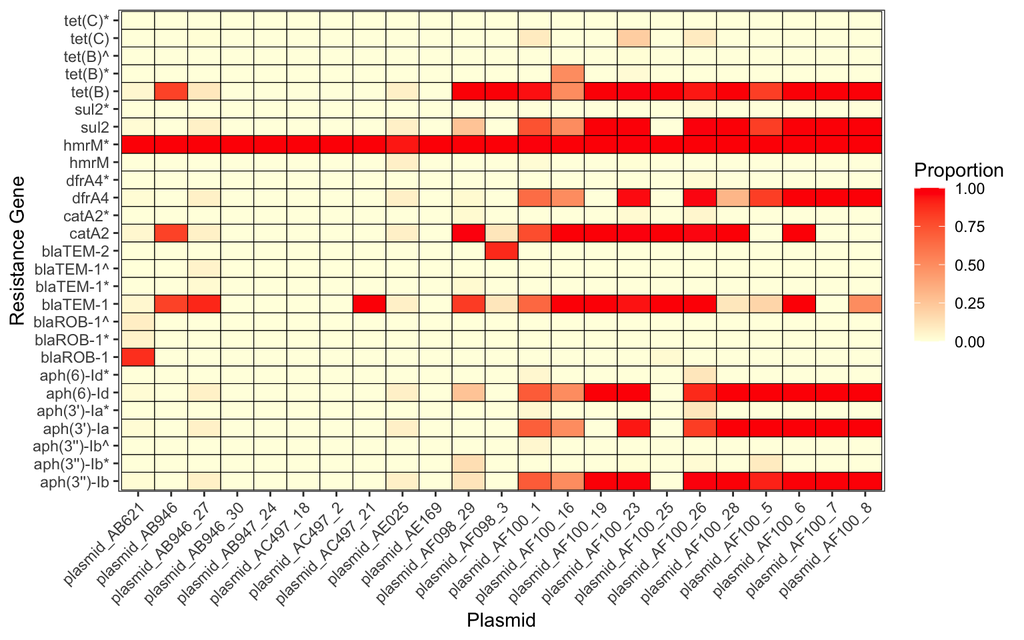

### Association between plasmids and resistance in *M. catarrhalis*

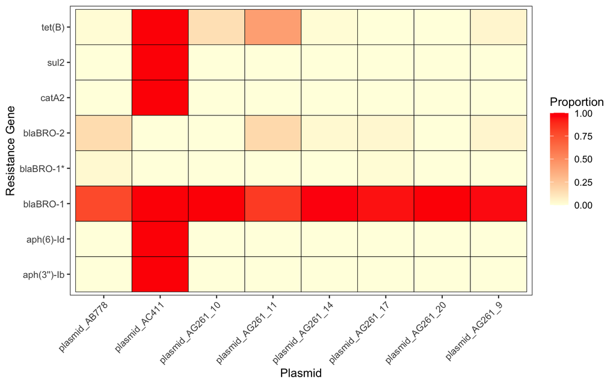

## Analysis of plasmid gene content

### Plasmids in *M. catarrhalis*

#### pAC411

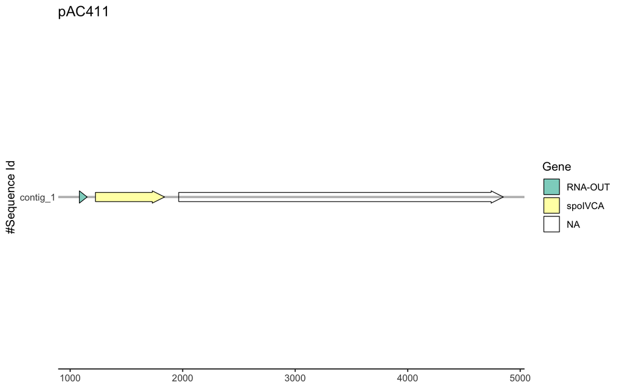

Use `plasmid_reclustering_df` to find representatives for annotation:

[1] “plasmid_AG261_9” “plasmid_AG261_10” “plasmid_AG261_11” “plasmid_AB778” “plasmid_AG261_14” “plasmid_AC411”  
[7] “plasmid_AG261_17” “plasmid_AG261_20”

For each one, search the dataframe, then use the “sample_name” column to find the right annotation (note you may have to replace the # character with an underscore).

### Plasmids in *H. influenzae*

Use `plasmid_reclustering_df` to find representatives for annotation:

[1] “plasmid_AF100_1” “plasmid_AB621” “plasmid_AF100_23” “plasmid_AF100_25” “plasmid_AF100_26” “plasmid_AB946_27” [7] “plasmid_AF100_28” “plasmid_AF098_29” “plasmid_AB946” “plasmid_AC497_2” “plasmid_AF098_3” “plasmid_AE025”  
[13] “plasmid_AB946_30” “plasmid_AF100_5” “plasmid_AF100_6” “plasmid_AF100_7” “plasmid_AF100_8” “plasmid_AF100_16” [19] “plasmid_AC497_18” “plasmid_AF100_19” “plasmid_AC497_21” “plasmid_AE169” “plasmid_AB947_24”

## Summarise single isolate epidemiology

### Generate microreact output files

Microreact visualisations are available from:

- *M. catarrhalis*: https://microreact.org/project/hQ9WcBim9Yspg9vEvVPWqr-moraxella-population-structure
- Serosensitive *M. catarrhalis*: https://microreact.org/project/gdU9T8EZNCXgQttppvuCVw-serosensitive-moraxella-poppunk
- Seroresistance *M. catarrhalis*: https://microreact.org/project/cYSZ1g2Scstfbg1hVpoe7r-seroresistant-moraxella-poppunk
- *H. influenzae*: https://microreact.org/project/qCSg4Ut9QYfAXo3tK3gTDu-h-influenzae-poppunk

## Compare strain frequencies between locations

### Plot distributions of strain frequencies across locations

### Compare *H. influenzae* strain frequencies between locations

TO DO

### Compare strain frequencies between locations

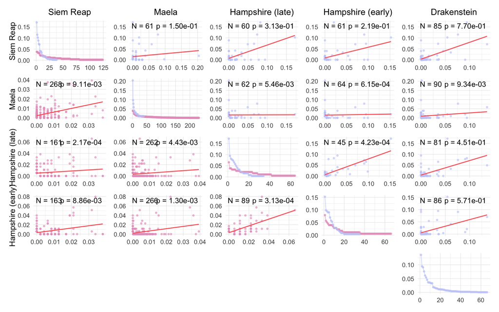

## Compare gene frequencies across locations

After we got the gene presence absence from *Moraxella catarrhalis* Panaroo, then we extracted that csv file for doing tidy column, calculate the gene frequencies and number of genomes then final plotting scatter graph and plot histograms between countries.

### Parse Panaroo output

This analysis used Panaroo version 1.5.2.

### Pangenome curve for *H. influenzae*

TO DO

### Pangenome curve for *M. catarrhalis*

TO DO

### Geographic analysis of gene frequencies

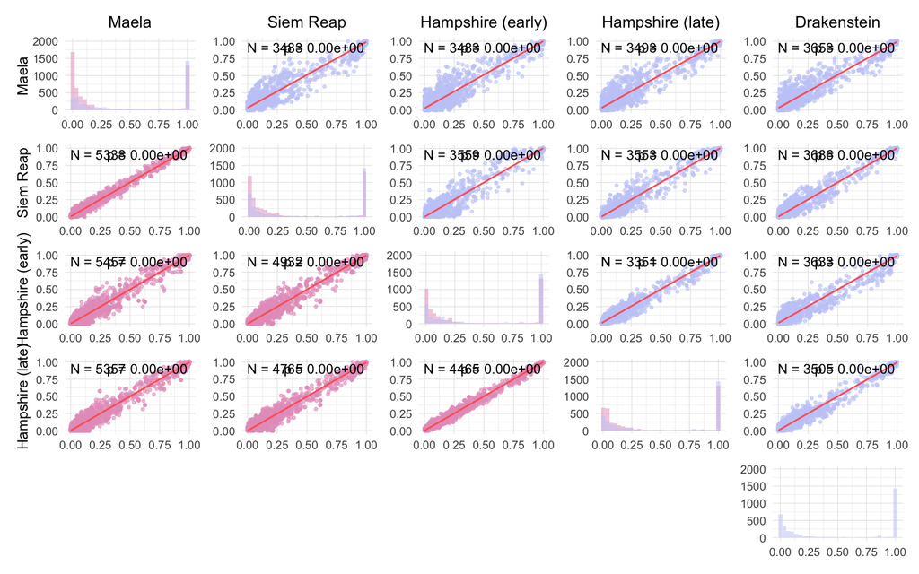

## Compare gene frequencies across locations

Key hypothesis for the evolution of plasmids is that they enable the local adaptation of strains. Therefore we can plot their frequency across locations.

### Frequency of plasmids across populations

### Frequency of plasmid-borne genes across populations

## Phylogenetic analysis

TO DO: Gubbins

### Analysis of recombination across populations

TO DO: fastGEAR

# Analysis of long-read data

## Assembling long-read data

## Long-read sequencing of representative isolates

These were chosen as:

- Representing the clusters with >9 isolates
- Plus representing any multidrug-resistance profiles not seen in the representatives of the most common clusters
- Only a subset were available for reculturing

## Methylation analyses from long-read data

Is the sharing of plasmids between species limited by RMS?

## Passage analysis from long-read data

# DNA methylation downstream analysis

## Import sample metadata

```
##                      Sample               Species
##                      <char>                <char>
## 1: 46472_2#312_day1_colony1 Moraxella catarrhalis
## 2:  46472_2#60_day1_colony1 Moraxella catarrhalis
## 3: 46358_2#292_day1_colony1 Moraxella catarrhalis
## 4: 46321_1#345_day1_colony1 Moraxella catarrhalis
## 5:              46321_1#181 Moraxella catarrhalis
## 6:              46472_2#373 Moraxella catarrhalis
```

This step imports sample metadata and species information for all long-read sequenced isolates.

# Import methylation motif calls

```
##         Sample             Motif      Motif_raw Methylation_type Genome_sites
##         <char>            <char>         <char>           <char>        <int>
## 1: 46321_1#127 No Motif Assigned           <NA>              5mC           NA
## 2: 46321_1#152 No Motif Assigned           <NA>              5mC           NA
## 3: 46321_1#181            AGCGSS 1-AAGCGSSTDDNK              5mC         1490
## 4: 46321_1#181          AAGCGCTT     3-AAGCGCTT              5mC           54
## 5: 46321_1#181 No Motif Assigned           <NA>              5mC           NA
## 6:  46321_1#20              GCGC 1-HMAAGCGCTTKD              5mC         2596
##    Methylated_sites Methylation_coverage Average_Percent_Methylation_per_site
##               <int>                <num>                                <num>
## 1:             1430                   NA                                 0.78
## 2:              323                   NA                                 0.83
## 3:             1121                0.752                                 0.82
## 4:               52                0.963                                 0.84
## 5:             3911                   NA                                 0.79
```

[output cut: 17 more lines]

Methylation motifs identified by MicrobeMod were combined into a single dataset for downstream analysis.

# Data cleaning and filtering

Samples containing only “No Motif Assigned” calls were separated from samples with identified motifs.

# Merge methylation and species metadata

```
##         Sample           Motif         Motif_raw Methylation_type Genome_sites
##         <char>          <char>            <char>           <char>        <int>
## 1: 46321_1#181          AGCGSS    1-AAGCGSSTDDNK              5mC         1490
## 2: 46321_1#181        AAGCGCTT        3-AAGCGCTT              5mC           54
## 3:  46321_1#20            GCGC    1-HMAAGCGCTTKD              5mC         2596
## 4: 46321_1#243           GCGCY    1-AGCGCYTRADWD              5mC         1634
## 5: 46321_1#243           ACGTK       2-ACGTKMTWV              5mC          188
## 6: 46321_1#243 AGCGCTGCMATMATW 3-AGCGCTGCMATMATW              5mC            5
##    Methylated_sites Methylation_coverage Average_Percent_Methylation_per_site
##               <num>                <num>                                <num>
## 1:             1121                0.752                                 0.82
## 2:               52                0.963                                 0.84
## 3:             1792                0.690                                 0.80
## 4:             1321                0.808                                 0.80
## 5:              186                0.989                                 0.85
```

[output cut: 17 more lines]

# Heatmap visualisation of methylation motifs

## Heatmap function

Heatmaps were generated to compare methylation motif distributions across species.

## Moraxella catarrhalis heatmap

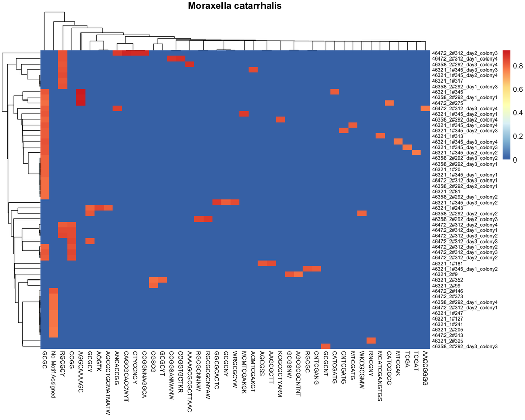

## Haemophilus influenzae heatmap

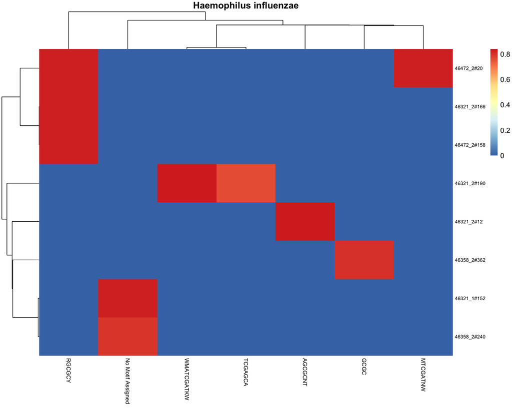

# ML probability analysis

## Import ML probability histograms

[output not shown]

Modification likelihood (ML) probability distributions were analysed to compare methylation confidence between samples.

# Density plot of ML probabilities

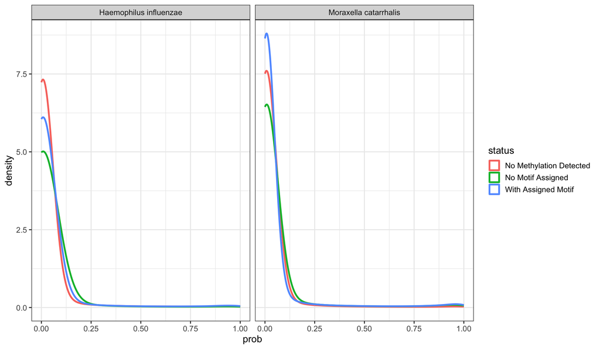

# Mean ML probability per sample

Modification likelihood (ML) probabilities were summarised per sample to compare methylation confidence across isolates with assigned motifs, no assigned motifs, and no detectable methylation.

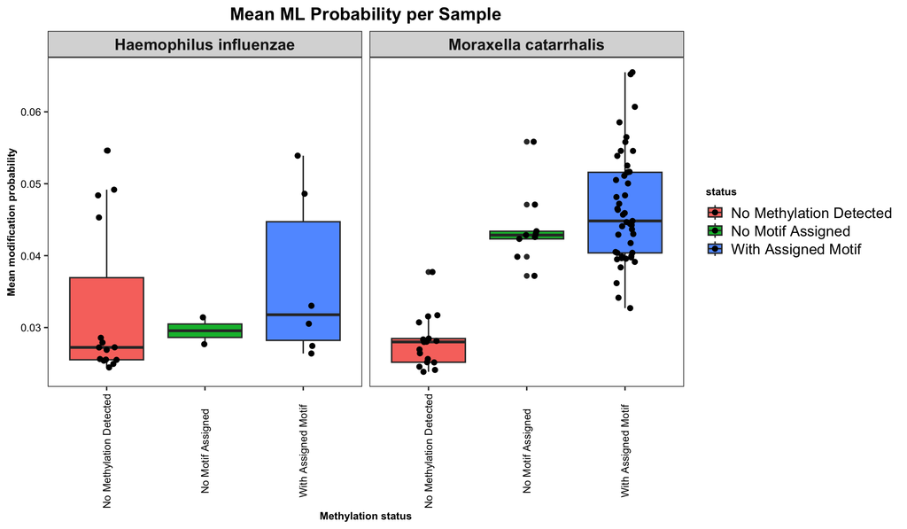